# 1.2.4 BT thực hành 2 - Online_retail

Tập dữ liệu này được lấy từ Kaggle, chứa thông tin giao dịch bán hàng của một công ty bán lẻ trực tuyến có trụ sở tại Vương quốc Anh. Dữ liệu ghi lại các đơn hàng được thực hiện trong khoảng thời gian từ tháng 12 năm 2010 đến tháng 12 năm 2011.

a. Mục tiêu sử dụng

- Phân tích hành vi mua sắm của khách hàng
- Trực quan hóa xu hướng tiêu dùng theo thời gian, quốc gia và sản phẩm
- Xây dựng các mô hình phân cụm hoặc dự đoán doanh thu

b. Các biến chính trong dữ liệu

- InvoiceNo: Mã số hóa đơn
- StockCode: Mã sản phẩm
- Description: Mô tả sản phẩm
- Quantity: Số lượng sản phẩm được mua
- InvoiceDate: Ngày giao dịch
- UnitPrice: Giá bán mỗi sản phẩm
- CustomerID: Mã khách hàng
- Country: Quốc gia của khách hàng

c. Đặc điểm nổi bật

- Dữ liệu thực tế, phản ánh hoạt động kinh doanh của doanh nghiệp
- Có thể phân tích theo thời gian, sản phẩm, quốc gia và khách hàng
- Phù hợp để thực hành trực quan hóa, phân tích RFM, phân cụm khách hàng và dự đoán doanh thu

d. Ứng dụng thực tế

- Hỗ trợ doanh nghiệp hiểu rõ hành vi tiêu dùng và tối ưu hóa chiến lược bán hàng
- Là nguồn dữ liệu lý tưởng để thực hành phân tích khách hàng, xây dựng dashboard hoặc mô hình học máy
- Có thể áp dụng các kỹ thuật như phân tích RFM, clustering, hoặc dự báo doanh thu theo thời gian

## 1. Chuẩn bị dữ liệu cho trực quan hóa dữ liệu

```python
# Import thư viện
import pandas as pd
import numpy as np
import matplotlib.pyplot as plt
import seaborn as sns

# Đọc dữ liệu
df = pd.read_excel('dataset/Online-Retail.xlsx')

# Xem sơ bộ
df.info()
# Hiển thị số lượng dòng và cột
print("Số lượng dòng (bản ghi):", df.shape[0])
print("Số lượng cột (biến):", df.shape[1])

# Xử lý dữ liệu
# Loại bỏ các dòng có giá trị thiếu ở CustomerID
df.dropna(subset=['CustomerID'], inplace=True)

# Loại bỏ các dòng có Quantity <= 0 hoặc UnitPrice <= 0
df = df[(df['Quantity'] > 0) & (df['UnitPrice'] > 0)]

# Tạo biến mới: Tổng giá trị đơn hàng
df['TotalPrice'] = df['Quantity'] * df['UnitPrice']

# Chuyển InvoiceDate sang kiểu datetime
df['InvoiceDate'] = pd.to_datetime(df['InvoiceDate'])
```

```
<class 'pandas.core.frame.DataFrame'>
RangeIndex: 541909 entries, 0 to 541908
Data columns (total 8 columns):
 #   Column       Non-Null Count   Dtype
---  ------       --------------   -----
 0   InvoiceNo    541909 non-null  object
 1   StockCode    541909 non-null  object
 2   Description  540455 non-null  object
 3   Quantity     541909 non-null  int64
 4   InvoiceDate  541909 non-null  datetime64[ns]
 5   UnitPrice    541909 non-null  float64
 6   CustomerID   406829 non-null  float64
 7   Country      541909 non-null  object
dtypes: datetime64[ns](1), float64(2), int64(1), object(4)
memory usage: 33.1+ MB
Số lượng dòng (bản ghi): 541909
Số lượng cột (biến): 8
```

## 2. Thiết lập kiểu hiển thị cho toàn bộ biểu đồ

```python
sns.set(style='whitegrid')
plt.rcParams['figure.figsize'] = (10, 6)
```

## 3. Biểu đồ phân phối giá trị đơn hàng (Histogram + KDE)

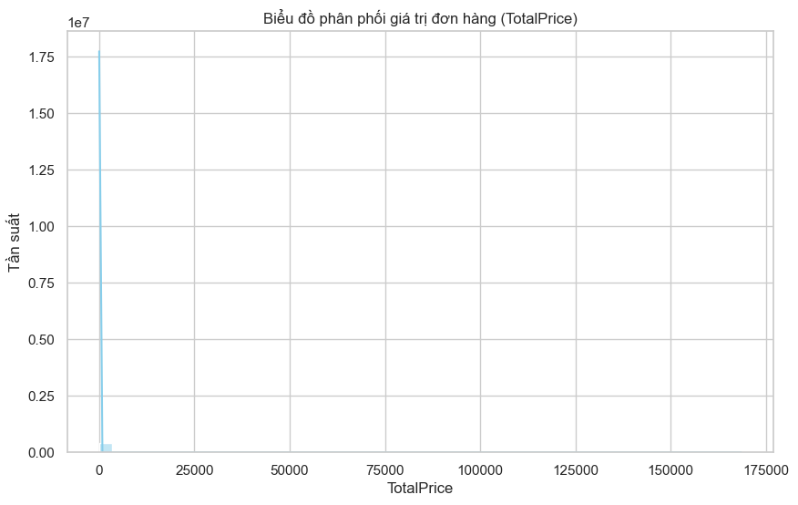

```python
sns.histplot(df['TotalPrice'], bins=50, kde=True, color='skyblue')
plt.title('Biểu đồ phân phối giá trị đơn hàng (TotalPrice)')
plt.xlabel('TotalPrice')
plt.ylabel('Tần suất')
plt.show()
```

### Nhận xét:

#### - Biểu đồ phân phối giá trị đơn hàng (TotalPrice)

Phần lớn đơn hàng có giá trị thấp, tập trung gần mức 0, cho thấy hành vi mua lẻ phổ biến. Các đơn hàng giá cao xuất hiện ít, phản ánh phân phối lệch phải rõ rệt.

## 4. Biểu đồ cột sản phẩm bán chạy nhất (Top 10)

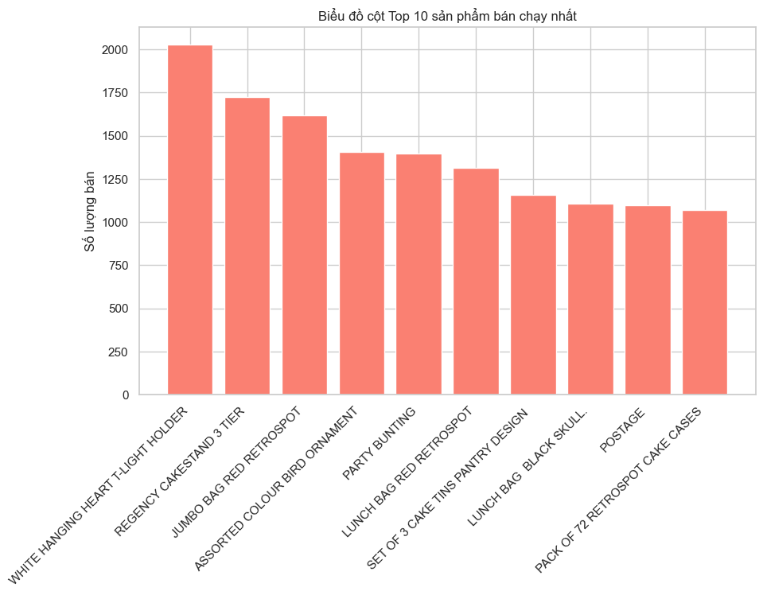

```python
top_products = df['Description'].value_counts().head(10)

plt.bar(top_products.index, top_products.values, color='salmon')
plt.title('Biểu đồ cột Top 10 sản phẩm bán chạy nhất')
plt.xticks(rotation=45, ha='right')
plt.ylabel('Số lượng bán')
plt.show()
```

## 5. Biểu đồ doanh thu theo quốc gia (Barplot)

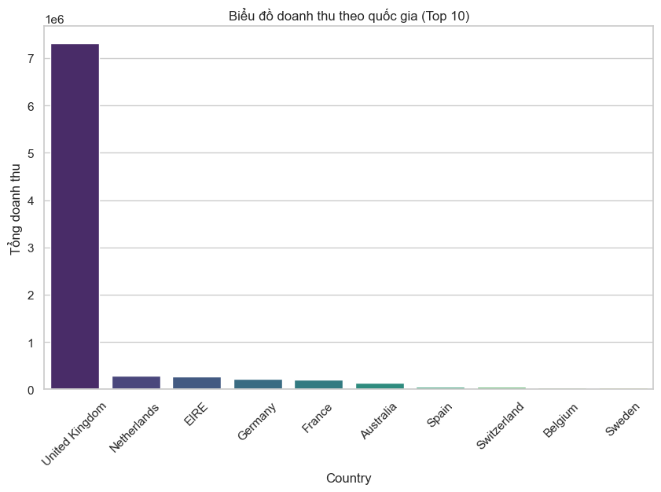

```python
country_sales = df.groupby('Country')['TotalPrice'].sum().sort_values(ascending=False).head(10)

sns.barplot(x=country_sales.index, y=country_sales.values, palette='viridis')
plt.title('Biểu đồ doanh thu theo quốc gia (Top 10)')
plt.ylabel('Tổng doanh thu')
plt.xticks(rotation=45)
plt.show()
```

### Nhận xét:

#### - Biểu đồ doanh thu theo quốc gia (Top 10)

Vương quốc Anh chiếm phần lớn doanh thu, vượt xa các quốc gia khác. Điều này phản ánh thị trường chính của doanh nghiệp và tiềm năng mở rộng tại các nước có doanh thu thấp hơn.

## 6. Biểu đồ đường doanh thu theo tháng (Lineplot)

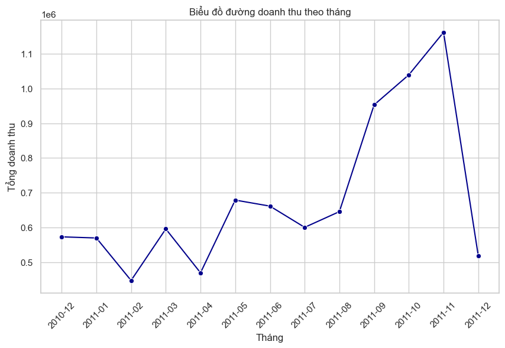

```python
df['Month'] = df['InvoiceDate'].dt.to_period('M')
monthly_sales = df.groupby('Month')['TotalPrice'].sum()

sns.lineplot(x=monthly_sales.index.astype(str), y=monthly_sales.values, marker='o', color='darkblue')
plt.title('Biểu đồ đường doanh thu theo tháng')
plt.xlabel('Tháng')
plt.ylabel('Tổng doanh thu')
plt.xticks(rotation=45)
plt.show()
```

### Nhận xét:

#### - Biểu đồ đường doanh thu theo tháng

Doanh thu tăng mạnh từ tháng 9 đến tháng 11/2011, với tháng 11 đạt mức cao nhất trong năm. Sau đó giảm mạnh trong tháng 12, mức giảm này cho thấy sự kết thúc của chu kỳ mua sắm cao điểm, có thể liên quan đến việc kết thúc mùa lễ hội hoặc thay đổi hành vi tiêu dùng. Xu hướng này phản ánh chu kỳ mua sắm cuối năm và hiệu quả của các chiến dịch bán hàng.